# GIS-Enhanced WOMart Sales Forecasting

Sairam Jammu

2026-05-28

# 1 Executive Summary

This project extends the WOMart sales forecasting workflow into a GIS-enabled retail analytics system. The original dataset supports store-level forecasting with sales history, holidays, discounts, store type, and region. This version adds simulated store coordinates and spatial features so the model output can support location-aware inventory planning, regional demand analysis, and GIS portfolio storytelling.

Because the source data does not include real store latitude and longitude, this analysis creates reproducible simulated coordinates by region. The GIS layer should be interpreted as a spatial analytics demonstration rather than a claim of real store locations.

# 2 Load Required Packages

```r
packages <- c(
  "tidyverse",
  "lubridate",
  "leaflet",
  "htmlwidgets",
  "ggplot2",
  "caret",
  "xgboost",
  "DT"
)

missing_packages <- packages[!packages %in% rownames(installed.packages())]

if (length(missing_packages) > 0) {
  install.packages(missing_packages, dependencies = TRUE)
}

library(tidyverse)
library(lubridate)
library(leaflet)
library(htmlwidgets)
library(ggplot2)
library(caret)
library(xgboost)
library(DT)
```

# 3 Load Dataset

```r
candidate_data_paths <- c(
  "data",
  "Sairam-Jammu-Capstone-Data",
  "../data",
  "../Sairam-Jammu-Capstone-Data"
)

data_path <- candidate_data_paths[dir.exists(candidate_data_paths)][1]

if (is.na(data_path)) {
  stop("Could not locate the project data folder.")
}

train_file <- list.files(data_path, pattern = "TRAIN", full.names = TRUE)[1]
test_file <- list.files(data_path, pattern = "TEST_FINAL", full.names = TRUE)[1]
sample_file <- list.files(data_path, pattern = "SAMPLE", full.names = TRUE)[1]

train <- read.csv(train_file)
test <- read.csv(test_file)
sample_submission <- read.csv(sample_file)

names(train) <- make.names(names(train))
names(test) <- make.names(names(test))
names(sample_submission) <- make.names(names(sample_submission))

data_inventory <- data.frame(
  Dataset = c("Train", "Test", "Sample Submission"),
  Rows = c(nrow(train), nrow(test), nrow(sample_submission)),
  Columns = c(ncol(train), ncol(test), ncol(sample_submission))
)

write.csv(data_inventory, file.path(table_dir, "data_inventory.csv"), row.names = FALSE)
data_inventory
```

```
##             Dataset   Rows Columns
## 1             Train 188340      10
## 2              Test  22265       8
## 3 Sample Submission  22265       2
```

The dataset contains historical store-level sales records plus store, region, discount, and holiday attributes. These fields are useful for both forecasting and spatial business analysis.

# 4 Clean and Feature Engineer Data

```r
convert_binary <- function(x) {
  x <- trimws(tolower(as.character(x)))
  ifelse(x %in% c("1", "yes", "y", "true", "holiday", "discount"), 1, 0)
}

create_time_features <- function(df) {
  df %>%
    mutate(
      Date = as.Date(Date),
      Holiday = convert_binary(Holiday),
      Discount = convert_binary(Discount),
      Year = year(Date),
      Month = month(Date),
      Week = week(Date),
      Day = day(Date),
      DayOfWeek = wday(Date, label = TRUE, abbr = TRUE),
      IsWeekend = ifelse(DayOfWeek %in% c("Sat", "Sun"), 1, 0)
    ) %>%
    arrange(Store_id, Date)
}

train <- create_time_features(train)
test <- create_time_features(test)

summary(train$Date)
```

```
##         Min.      1st Qu.       Median         Mean      3rd Qu.         Max.
## "2018-01-01" "2018-05-09" "2018-09-15" "2018-09-15" "2019-01-22" "2019-05-31"
```

```r
summary(test$Date)
```

```
##         Min.      1st Qu.       Median         Mean      3rd Qu.         Max.
## "2019-06-01" "2019-06-16" "2019-07-01" "2019-07-01" "2019-07-16" "2019-07-31"
```

Date, holiday, discount, weekend, and calendar features help the model capture retail seasonality, promotional effects, and operational timing.

# 5 Create GIS Store Coordinates

```r
set.seed(123)

store_locations <- train %>%
  distinct(Store_id, Store_Type, Location_Type, Region_Code) %>%
  mutate(
    Latitude = case_when(
      Region_Code == "R1" ~ runif(n(), 40.1, 41.8),
      Region_Code == "R2" ~ runif(n(), 38.5, 40.0),
      Region_Code == "R3" ~ runif(n(), 35.5, 37.5),
      Region_Code == "R4" ~ runif(n(), 33.5, 35.0),
      TRUE ~ runif(n(), 36.0, 41.0)
    ),
    Longitude = case_when(
      Region_Code == "R1" ~ runif(n(), -83.0, -80.0),
      Region_Code == "R2" ~ runif(n(), -86.0, -83.0),
      Region_Code == "R3" ~ runif(n(), -89.0, -86.0),
      Region_Code == "R4" ~ runif(n(), -92.0, -89.0),
      TRUE ~ runif(n(), -92.0, -80.0)
    )
  )

write.csv(store_locations, file.path(table_dir, "simulated_store_locations.csv"), row.names = FALSE)
head(store_locations)
```

```
##   Store_id Store_Type Location_Type Region_Code Latitude Longitude
## 1        1         S1            L3          R1 40.58888 -80.35521
## 2        2         S3            L1          R3 37.24976 -87.63057
## 3        3         S4            L2          R1 40.79526 -80.35570
## 4        4         S1            L1          R2 39.10991 -83.20894
## 5        5         S1            L1          R3 35.84445 -88.30250
## 6        6         S4            L1          R1 40.17745 -80.40922
```

The simulated coordinates allow the project to demonstrate mapping, spatial clustering, and location-aware forecasting logic.

# 6 Join GIS Coordinates

```r
train_gis <- train %>%
  left_join(store_locations, by = c("Store_id", "Store_Type", "Location_Type", "Region_Code"))

test_gis <- test %>%
  left_join(store_locations, by = c("Store_id", "Store_Type", "Location_Type", "Region_Code"))

center_lat <- mean(store_locations$Latitude, na.rm = TRUE)
center_lon <- mean(store_locations$Longitude, na.rm = TRUE)

add_spatial_features <- function(df) {
  df %>%
    mutate(
      Distance_To_Center = sqrt((Latitude - center_lat)^2 + (Longitude - center_lon)^2),
      Holiday_Discount = Holiday * Discount,
      Region_Store_Key = paste(Region_Code, Store_Type, sep = "_")
    )
}

train_gis <- add_spatial_features(train_gis)
test_gis <- add_spatial_features(test_gis)

head(train_gis)
```

```
##         ID Store_id Store_Type Location_Type Region_Code       Date Holiday
## 1 T1000001        1         S1            L3          R1 2018-01-01       1
## 2 T1000608        1         S1            L3          R1 2018-01-02       0
## 3 T1001047        1         S1            L3          R1 2018-01-03       0
## 4 T1001208        1         S1            L3          R1 2018-01-04       0
## 5 T1001753        1         S1            L3          R1 2018-01-05       0
## 6 T1002163        1         S1            L3          R1 2018-01-06       0
##   Discount X.Order    Sales Year Month Week Day DayOfWeek IsWeekend Latitude
## 1        1       9  7011.84 2018     1    1   1       Mon         0 40.58888
## 2        1      60 42369.00 2018     1    1   2       Tue         0 40.58888
## 3        1      72 50037.00 2018     1    1   3       Wed         0 40.58888
## 4        1      64 44397.00 2018     1    1   4       Thu         0 40.58888
## 5        1      63 47604.00 2018     1    1   5       Fri         0 40.58888
## 6        0      36 24495.00 2018     1    1   6       Sat         1 40.58888
##   Longitude Distance_To_Center Holiday_Discount Region_Store_Key
## 1 -80.35521           5.152063                1            R1_S1
## 2 -80.35521           5.152063                0            R1_S1
## 3 -80.35521           5.152063                0            R1_S1
## 4 -80.35521           5.152063                0            R1_S1
## 5 -80.35521           5.152063                0            R1_S1
## 6 -80.35521           5.152063                0            R1_S1
```

The forecasting dataset is now GIS-enabled. Each row includes store coordinates and spatial distance features.

# 7 Store-Level GIS Sales Summary

```r
store_sales_summary <- train_gis %>%
  group_by(Store_id, Store_Type, Location_Type, Region_Code, Latitude, Longitude) %>%
  summarise(
    Avg_Sales = mean(Sales, na.rm = TRUE),
    Total_Sales = sum(Sales, na.rm = TRUE),
    Sales_SD = sd(Sales, na.rm = TRUE),
    Discount_Rate = mean(Discount, na.rm = TRUE),
    .groups = "drop"
  )

write.csv(store_sales_summary, file.path(table_dir, "store_sales_summary.csv"), row.names = FALSE)
head(store_sales_summary)
```

```
## # A tibble: 6 × 10
##   Store_id Store_Type Location_Type Region_Code Latitude Longitude Avg_Sales
##      <int> <chr>      <chr>         <chr>          <dbl>     <dbl>     <dbl>
## 1        1 S1         L3            R1              40.6     -80.4    34698.
## 2        2 S3         L1            R3              37.2     -87.6    46334.
## 3        3 S4         L2            R1              40.8     -80.4    62479.
## 4        4 S1         L1            R2              39.1     -83.2    38482.
## 5        5 S1         L1            R3              35.8     -88.3    43453.
## 6        6 S4         L1            R1              40.2     -80.4    45360.
## # ℹ 3 more variables: Total_Sales <dbl>, Sales_SD <dbl>, Discount_Rate <dbl>
```

This table shows average sales, total sales, volatility, and discount frequency by store. It provides a location-aware view of demand performance.

# 8 Interactive GIS Store Map

```r
sales_map <- leaflet(store_sales_summary) %>%
  addTiles() %>%
  addCircleMarkers(
    lng = ~Longitude,
    lat = ~Latitude,
    radius = ~sqrt(Avg_Sales) / 25,
    popup = ~paste0(
      "<b>Store ID:</b> ", Store_id,
      "<br><b>Region:</b> ", Region_Code,
      "<br><b>Store Type:</b> ", Store_Type,
      "<br><b>Average Sales:</b> ", round(Avg_Sales, 2),
      "<br><b>Total Sales:</b> ", round(Total_Sales, 2),
      "<br><b>Sales Volatility:</b> ", round(Sales_SD, 2),
      "<br><b>Discount Rate:</b> ", round(Discount_Rate, 2)
    ),
    color = "#2563eb",
    fillColor = "#2563eb",
    fillOpacity = 0.7
  )

saveWidget(sales_map, file.path(map_dir, "store_sales_gis_map.html"), selfcontained = TRUE)
sales_map
```

[interactive chart not shown]

The interactive map helps identify high-performing store locations and regions with stronger sales activity.

# 9 Exploratory GIS Visuals

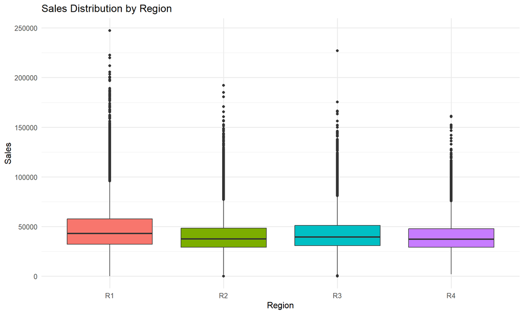

```r
plot_region <- ggplot(train_gis, aes(x = Region_Code, y = Sales, fill = Region_Code)) +
  geom_boxplot(show.legend = FALSE) +
  labs(title = "Sales Distribution by Region", x = "Region", y = "Sales") +
  theme_minimal(base_size = 12) +
  theme(plot.background = element_rect(fill = "white", color = NA))

plot_store_type <- ggplot(train_gis, aes(x = Store_Type, y = Sales, fill = Store_Type)) +
  geom_boxplot(show.legend = FALSE) +
  labs(title = "Sales Distribution by Store Type", x = "Store Type", y = "Sales") +
  theme_minimal(base_size = 12) +
  theme(plot.background = element_rect(fill = "white", color = NA))

daily_sales <- train_gis %>%
  group_by(Date) %>%
  summarise(Total_Sales = sum(Sales, na.rm = TRUE), .groups = "drop")

plot_time <- ggplot(daily_sales, aes(x = Date, y = Total_Sales)) +
  geom_line(color = "#2563eb") +
  labs(title = "Total WOMart Sales Over Time", x = "Date", y = "Total Sales") +
  theme_minimal(base_size = 12) +
  theme(plot.background = element_rect(fill = "white", color = NA))

promo_region <- train_gis %>%
  group_by(Region_Code, Discount) %>%
  summarise(Avg_Sales = mean(Sales, na.rm = TRUE), .groups = "drop")

plot_promo <- ggplot(promo_region, aes(x = Region_Code, y = Avg_Sales, fill = as.factor(Discount))) +
  geom_col(position = "dodge") +
  labs(title = "Promotion Impact by Region", x = "Region", y = "Average Sales", fill = "Discount") +
  theme_minimal(base_size = 12) +
  theme(plot.background = element_rect(fill = "white", color = NA))

holiday_region <- train_gis %>%
  group_by(Region_Code, Holiday) %>%
  summarise(Avg_Sales = mean(Sales, na.rm = TRUE), .groups = "drop")

plot_holiday <- ggplot(holiday_region, aes(x = Region_Code, y = Avg_Sales, fill = as.factor(Holiday))) +
  geom_col(position = "dodge") +
  labs(title = "Holiday Impact by Region", x = "Region", y = "Average Sales", fill = "Holiday") +
  theme_minimal(base_size = 12) +
  theme(plot.background = element_rect(fill = "white", color = NA))

ggsave(file.path(plot_dir, "sales_distribution_by_region.png"), plot_region, width = 10, height = 6, dpi = 160, bg = "white")
ggsave(file.path(plot_dir, "sales_distribution_by_store_type.png"), plot_store_type, width = 10, height = 6, dpi = 160, bg = "white")
ggsave(file.path(plot_dir, "total_sales_over_time.png"), plot_time, width = 10, height = 6, dpi = 160, bg = "white")
ggsave(file.path(plot_dir, "promotion_impact_by_region.png"), plot_promo, width = 10, height = 6, dpi = 160, bg = "white")
ggsave(file.path(plot_dir, "holiday_impact_by_region.png"), plot_holiday, width = 10, height = 6, dpi = 160, bg = "white")

plot_region
```

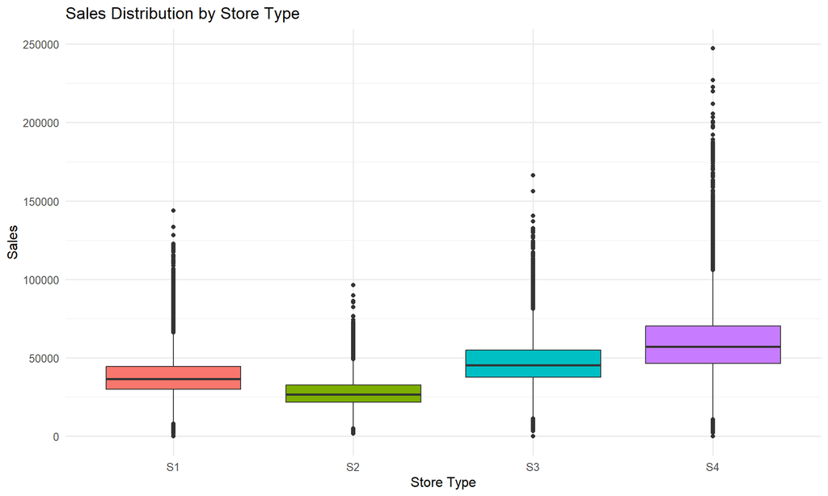

```r
plot_store_type
```

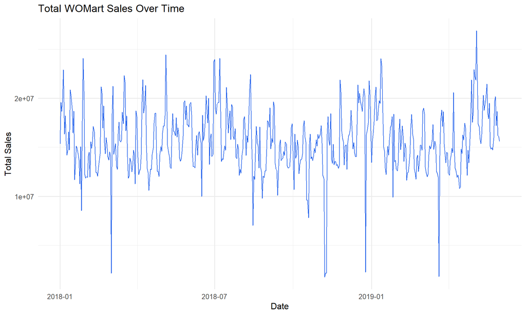

```r
plot_time
```

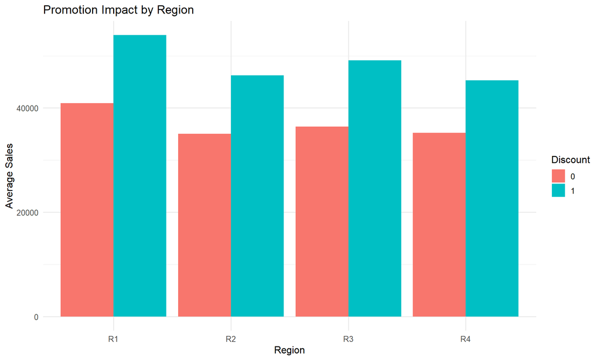

```r
plot_promo
```

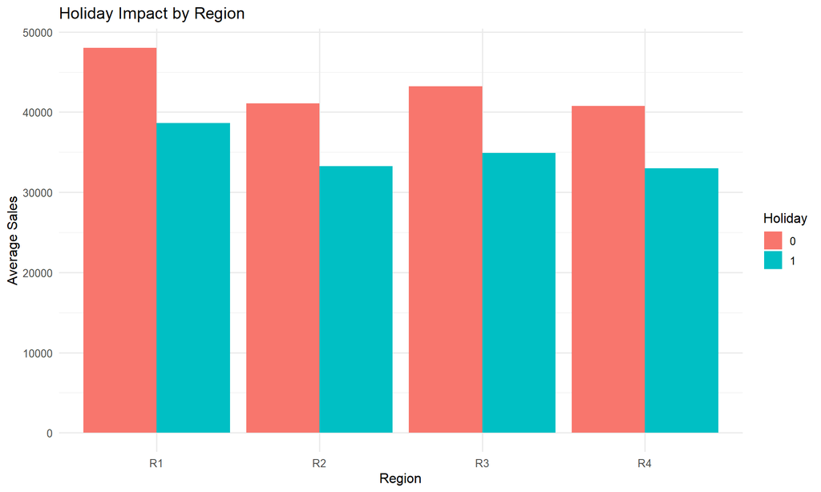

```r
plot_holiday
```

These visuals show differences in sales behavior by geography, store format, promotions, holidays, and time. The GIS framing makes the outputs easier to use for regional planning.

# 10 Modeling Dataset

```r
missing_summary <- data.frame(
  Column = names(train_gis),
  Missing_Count = colSums(is.na(train_gis))
)

write.csv(missing_summary, file.path(table_dir, "missing_value_summary.csv"), row.names = FALSE)

model_data <- train_gis %>%
  select(
    Sales,
    Store_id,
    Store_Type,
    Location_Type,
    Region_Code,
    Discount,
    Holiday,
    Month,
    Week,
    Day,
    IsWeekend,
    Latitude,
    Longitude,
    Distance_To_Center,
    Holiday_Discount
  ) %>%
  na.omit() %>%
  mutate(
    Store_id = as.factor(Store_id),
    Store_Type = as.factor(Store_Type),
    Location_Type = as.factor(Location_Type),
    Region_Code = as.factor(Region_Code)
  )

train_index <- createDataPartition(model_data$Sales, p = 0.8, list = FALSE)
train_model <- model_data[train_index, ]
valid_model <- model_data[-train_index, ]

x_train_data <- train_model %>% select(-Sales)
x_valid_data <- valid_model %>% select(-Sales)

dummy_model <- dummyVars(~ ., data = x_train_data)

x_train <- predict(dummy_model, newdata = x_train_data)
x_valid <- predict(dummy_model, newdata = x_valid_data)

y_train <- train_model$Sales
y_valid <- valid_model$Sales

data.frame(
  Split = c("Training", "Validation"),
  Rows = c(nrow(train_model), nrow(valid_model))
)
```

```
##        Split   Rows
## 1   Training 150674
## 2 Validation  37666
```

The model uses store identifiers, store type, region, promotions, holidays, time features, and GIS features to predict sales.

# 11 Train XGBoost Model

```r
dtrain <- xgb.DMatrix(data = x_train, label = y_train)
dvalid <- xgb.DMatrix(data = x_valid, label = y_valid)

params <- list(
  objective = "reg:squarederror",
  eval_metric = "rmse",
  eta = 0.05,
  max_depth = 6,
  subsample = 0.8,
  colsample_bytree = 0.8
)

xgb_model <- xgb.train(
  params = params,
  data = dtrain,
  nrounds = 300,
  watchlist = list(train = dtrain, valid = dvalid),
  early_stopping_rounds = 20,
  verbose = 1
)
```

```
## Multiple eval metrics are present. Will use valid_rmse for early stopping.
## Will train until valid_rmse hasn't improved in 20 rounds.
##
```

XGBoost is suitable here because it can capture non-linear relationships among spatial, temporal, promotional, and store-level variables.

# 12 Validate Model Performance

```r
valid_pred <- predict(xgb_model, dvalid)
valid_pred <- pmax(valid_pred, 0)

rmse <- sqrt(mean((y_valid - valid_pred)^2))
mae <- mean(abs(y_valid - valid_pred))
msle <- mean((log1p(y_valid) - log1p(valid_pred))^2)
r_squared <- cor(y_valid, valid_pred)^2

metrics <- data.frame(
  Metric = c("RMSE", "MAE", "MSLE", "R_Squared"),
  Value = c(rmse, mae, msle, r_squared)
)

write.csv(metrics, file.path(table_dir, "model_validation_metrics.csv"), row.names = FALSE)
metrics
```

```
##      Metric        Value
## 1      RMSE 9.279500e+03
## 2       MAE 6.523384e+03
## 3      MSLE 6.896804e-02
## 4 R_Squared 7.521102e-01
```

RMSE measures larger forecast errors, MAE shows average sales-unit error, MSLE is useful for wide-ranging sales values, and R-squared indicates the share of variance captured by the model.

# 13 Actual vs Predicted Sales

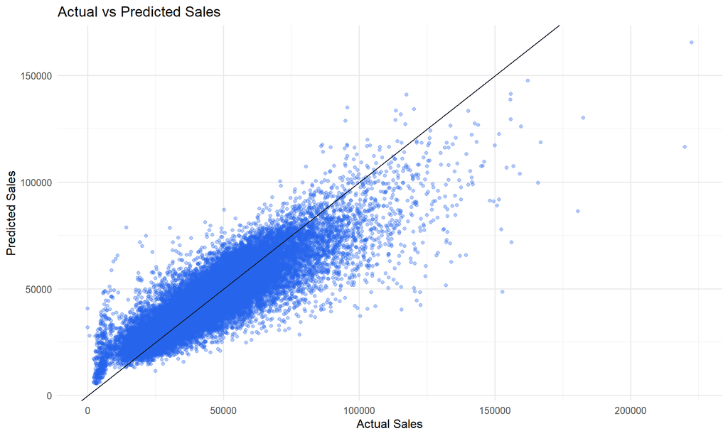

```r
prediction_results <- data.frame(Actual = y_valid, Predicted = valid_pred)

plot_actual_predicted <- ggplot(prediction_results, aes(x = Actual, y = Predicted)) +
  geom_point(alpha = 0.35, color = "#2563eb") +
  geom_abline(slope = 1, intercept = 0, color = "#111827") +
  labs(title = "Actual vs Predicted Sales", x = "Actual Sales", y = "Predicted Sales") +
  theme_minimal(base_size = 12) +
  theme(plot.background = element_rect(fill = "white", color = NA))

ggsave(file.path(plot_dir, "actual_vs_predicted_sales.png"), plot_actual_predicted, width = 10, height = 6, dpi = 160, bg = "white")
plot_actual_predicted
```

Points closer to the diagonal line indicate stronger prediction accuracy. Large deviations indicate unusual demand events or local conditions.

# 14 Feature Importance

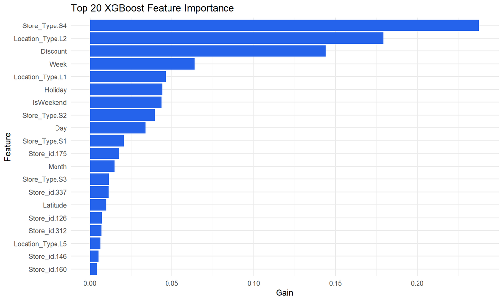

```r
importance <- xgb.importance(feature_names = colnames(x_train), model = xgb_model)
write.csv(importance, file.path(table_dir, "feature_importance.csv"), row.names = FALSE)

importance_top <- importance %>%
  as_tibble() %>%
  slice_max(Gain, n = 20) %>%
  mutate(Feature = reorder(Feature, Gain))

plot_importance <- ggplot(importance_top, aes(x = Gain, y = Feature)) +
  geom_col(fill = "#2563eb") +
  labs(
    title = "Top 20 XGBoost Feature Importance",
    x = "Gain",
    y = "Feature"
  ) +
  theme_minimal(base_size = 12) +
  theme(plot.background = element_rect(fill = "white", color = NA))

ggsave(file.path(plot_dir, "xgboost_feature_importance.png"), plot_importance, width = 10, height = 7, dpi = 160, bg = "white")
plot_importance
```

Feature importance improves model transparency by showing which time, promotion, store, region, and spatial features most strongly influence sales predictions.

# 15 Generate Forecasts

```r
test_model <- test_gis %>%
  select(
    Store_id,
    Store_Type,
    Location_Type,
    Region_Code,
    Discount,
    Holiday,
    Month,
    Week,
    Day,
    IsWeekend,
    Latitude,
    Longitude,
    Distance_To_Center,
    Holiday_Discount
  ) %>%
  mutate(
    Store_id = as.factor(Store_id),
    Store_Type = as.factor(Store_Type),
    Location_Type = as.factor(Location_Type),
    Region_Code = as.factor(Region_Code)
  )

x_test <- predict(dummy_model, newdata = test_model)
dtest <- xgb.DMatrix(data = x_test)

test_gis$Predicted_Sales <- predict(xgb_model, dtest)
test_gis$Predicted_Sales <- pmax(test_gis$Predicted_Sales, 0)

final_output <- test_gis %>%
  select(
    Store_id,
    Date,
    Region_Code,
    Store_Type,
    Location_Type,
    Latitude,
    Longitude,
    Predicted_Sales
  )

write.csv(final_output, file.path(output_dir, "GIS_WOMart_Forecast_Output.csv"), row.names = FALSE)
write.csv(final_output, "GIS_WOMart_Forecast_Output.csv", row.names = FALSE)

head(final_output)
```

```
##   Store_id       Date Region_Code Store_Type Location_Type Latitude Longitude
## 1        1 2019-06-01          R1         S1            L3 40.58888 -80.35521
## 2        1 2019-06-02          R1         S1            L3 40.58888 -80.35521
## 3        1 2019-06-03          R1         S1            L3 40.58888 -80.35521
## 4        1 2019-06-04          R1         S1            L3 40.58888 -80.35521
## 5        1 2019-06-05          R1         S1            L3 40.58888 -80.35521
## 6        1 2019-06-06          R1         S1            L3 40.58888 -80.35521
##   Predicted_Sales
## 1        40285.36
## 2        37519.92
## 3        30110.72
## 4        30232.57
## 5        29727.55
## 6        30232.57
```

The output includes future sales predictions with GIS coordinates, making it ready for maps, dashboards, and regional planning.

# 16 Forecast Summary by Store and Region

```r
forecast_summary <- test_gis %>%
  group_by(Store_id, Store_Type, Location_Type, Region_Code, Latitude, Longitude) %>%
  summarise(
    Forecasted_Sales = mean(Predicted_Sales, na.rm = TRUE),
    Forecast_SD = sd(Predicted_Sales, na.rm = TRUE),
    .groups = "drop"
  )

regional_forecast <- forecast_summary %>%
  group_by(Region_Code) %>%
  summarise(
    Avg_Forecasted_Sales = mean(Forecasted_Sales, na.rm = TRUE),
    Avg_Forecast_Volatility = mean(Forecast_SD, na.rm = TRUE),
    Store_Count = n(),
    .groups = "drop"
  ) %>%
  arrange(desc(Avg_Forecasted_Sales))

write.csv(forecast_summary, file.path(table_dir, "forecast_summary_by_store.csv"), row.names = FALSE)
write.csv(regional_forecast, file.path(table_dir, "regional_forecast_summary.csv"), row.names = FALSE)

regional_forecast
```

```
## # A tibble: 4 × 4
##   Region_Code Avg_Forecasted_Sales Avg_Forecast_Volatility Store_Count
##   <chr>                      <dbl>                   <dbl>       <int>
## 1 R1                        49584.                   7902.         124
## 2 R3                        44827.                   7553.          86
## 3 R2                        42666.                   6838.         105
## 4 R4                        42444.                   6743.          50
```

Regions with higher average forecasted sales should receive stronger inventory planning. Regions with higher volatility may require buffer stock and closer monitoring.

# 17 Forecast GIS Map

```r
forecast_map <- leaflet(forecast_summary) %>%
  addTiles() %>%
  addCircleMarkers(
    lng = ~Longitude,
    lat = ~Latitude,
    radius = ~sqrt(Forecasted_Sales) / 25,
    popup = ~paste0(
      "<b>Store ID:</b> ", Store_id,
      "<br><b>Region:</b> ", Region_Code,
      "<br><b>Store Type:</b> ", Store_Type,
      "<br><b>Forecasted Sales:</b> ", round(Forecasted_Sales, 2),
      "<br><b>Forecast Volatility:</b> ", round(Forecast_SD, 2)
    ),
    color = "#16a34a",
    fillColor = "#16a34a",
    fillOpacity = 0.7
  )

saveWidget(forecast_map, file.path(map_dir, "forecast_sales_gis_map.html"), selfcontained = TRUE)
forecast_map
```

[interactive chart not shown]

The forecast map shows where future demand is expected to be stronger. Larger green circles indicate stores with higher predicted sales.

# 18 Final Business Interpretation

The GIS-enhanced forecasting model combines sales history, store characteristics, promotions, holidays, temporal patterns, and spatial features. This converts a traditional retail forecasting task into a spatial decision-support workflow.

High-performing regions and stores can be prioritized for inventory expansion. Volatile areas may require buffer stock and closer monitoring. Stable regions can use leaner replenishment strategies. The map-based outputs make the results easier to interpret for stakeholders who need to make location-based planning decisions.

The simulated GIS layer also demonstrates transferable GIS experience: coordinate generation, spatial feature engineering, interactive mapping, regional segmentation, and map-ready forecast outputs.